# Haron Shihab

# Univariate Plots Section

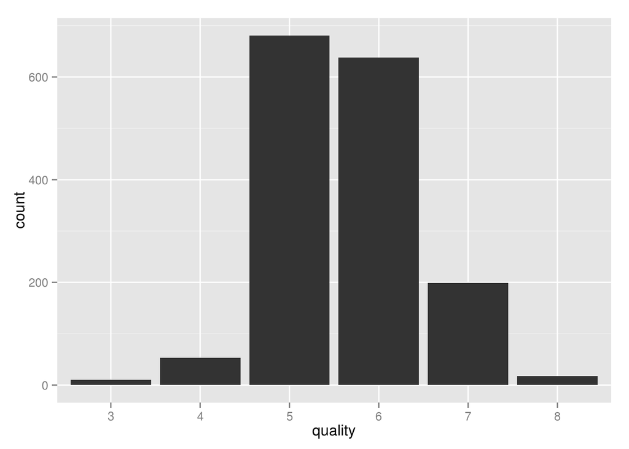

Notes:

Looks like a quality rating of `5` and `6` are common, red wines of really high quality and really bad quality are scarce.

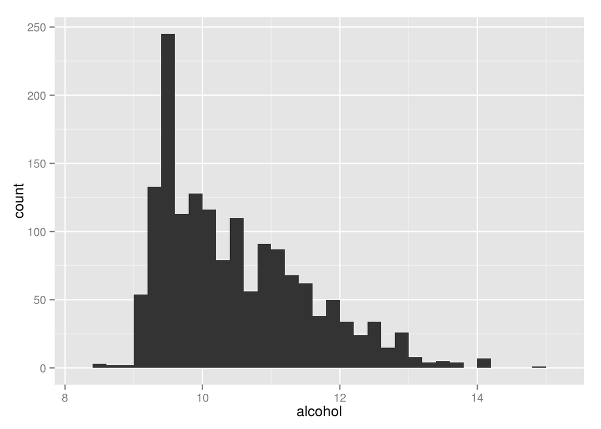

Notes:

We have seen from the quality histogram that a rating of 5 & 6 are common, and from this plot we see that an alcohol level of around 10% is also common, maybe that’s why we see alot of 5 & 6 ratings ?, does higher alcohol results in a higher wine quality?

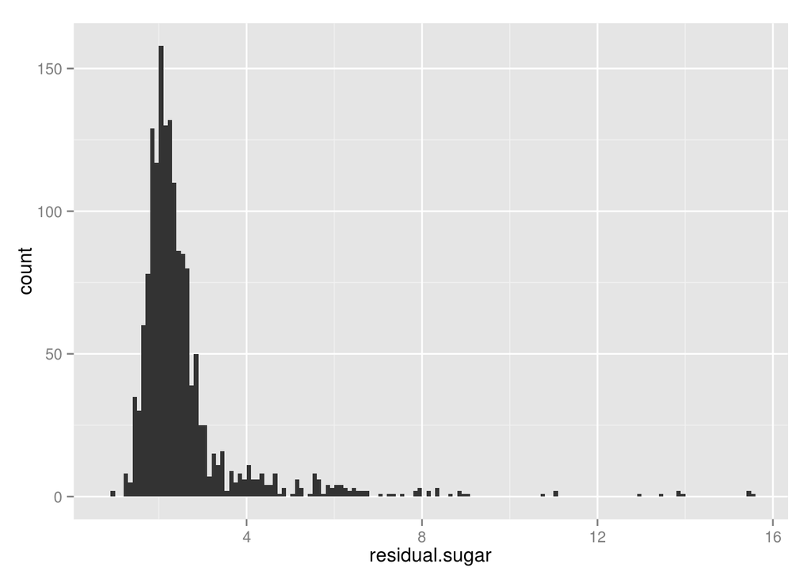

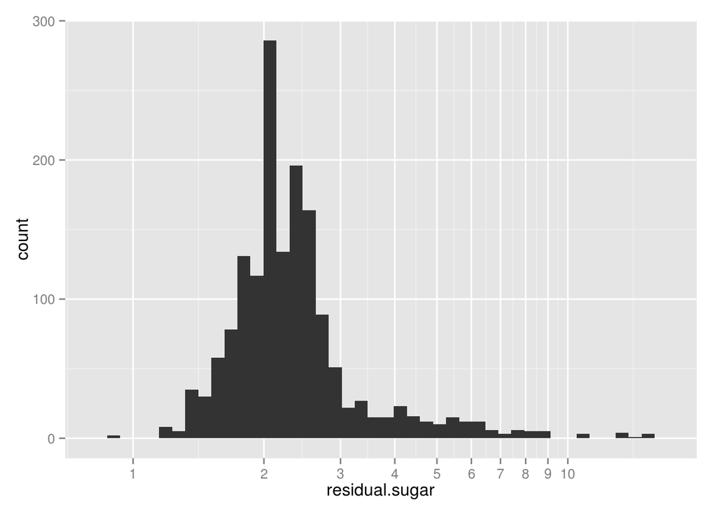

Notes:

Most red wines have an amount of sugar around 2g / dm^3, `mean` is 2.5388055, `median` is 2.2

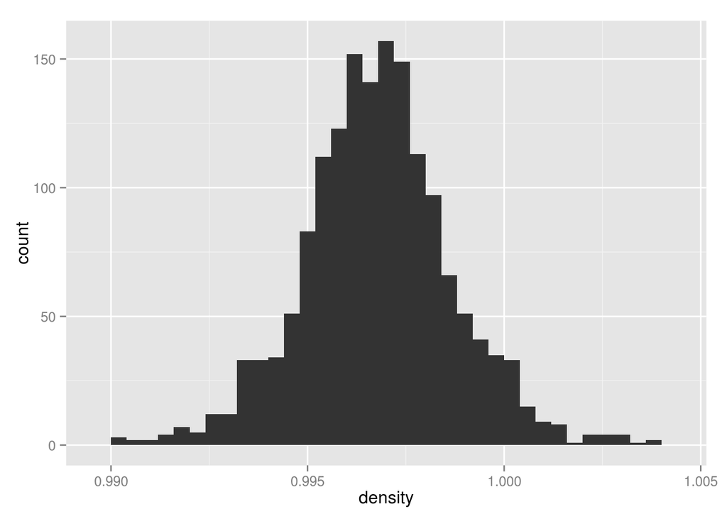

Notes:

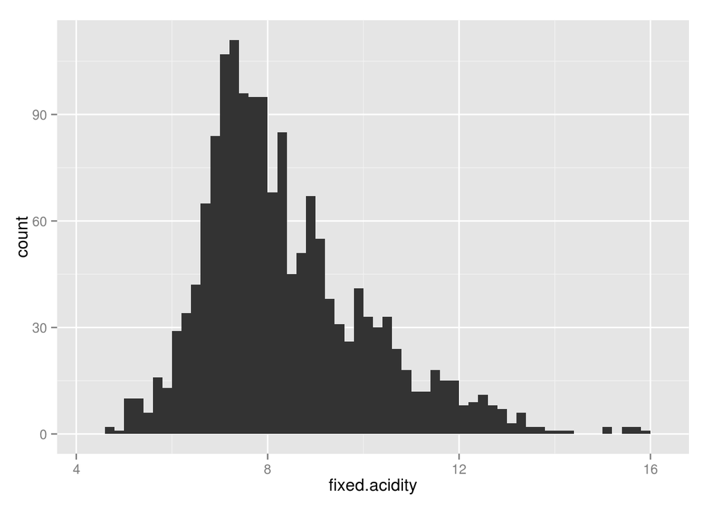

Notes:

Most wines have a fixed acidity level of ~ 8 g / dm^3

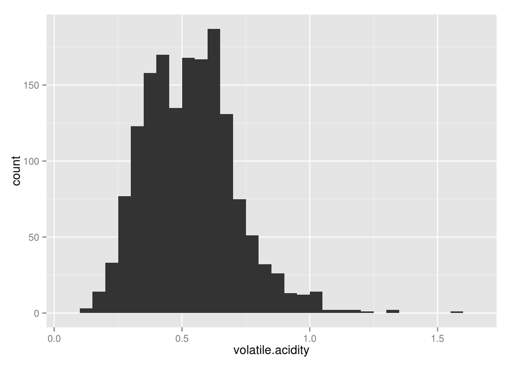

Notes:

Most wines have a volatile acidity(acedic acid) level of ~ 0.5 g / dm^3

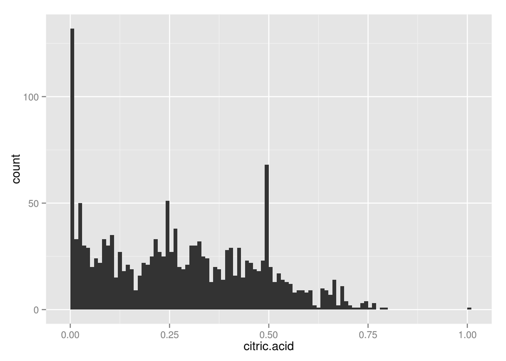

Notes:

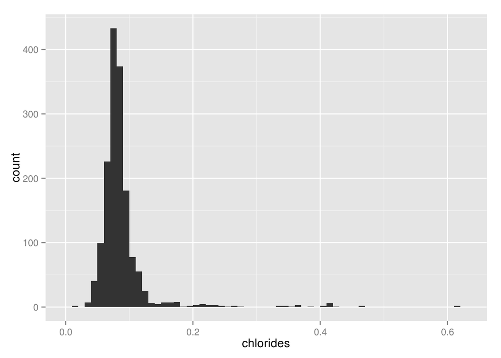

Most wines have a level of chlorides around 0.1 g / dm^3

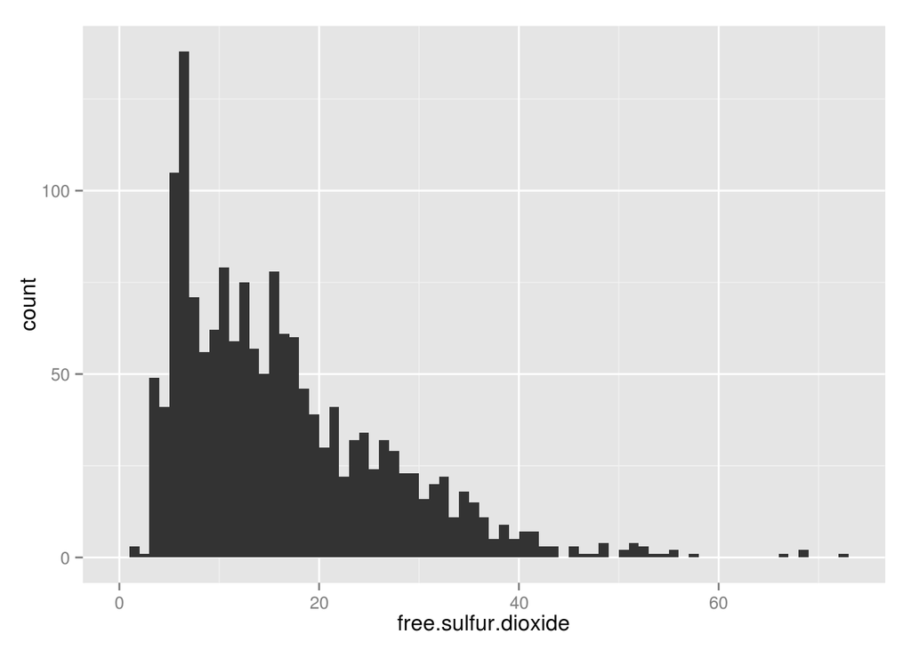

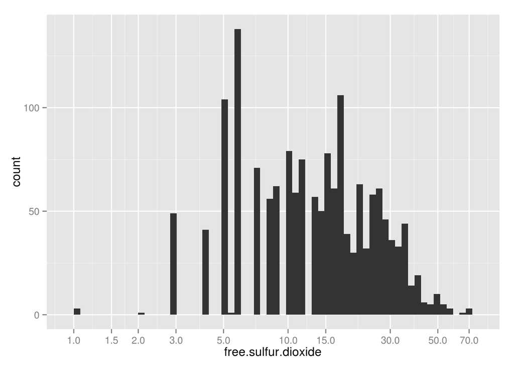

Since the histogram of free sulfur dioxide seems skewed, i’m going to transform the data using log transorm. It seems that this variable does not have fractions (meaning that it’s an integer in most of the cases) which seems a bit weird to see an exact amount of free sulfur dioxide, This is maybe caused due to rounding. I think this is what’s making some free sulfur dioxide values non existent in the histogram.

There are some values that are more common than others

```
##
##    6    5   10   15   12    7    9   16   17   11   13    8   14    3   18
##  138  104   79   78   75   71   62   61   60   59   57   56   50   49   46
##    4   21   19   24   23   26   20   27   25   28   29   22   32   31   34
##   41   41   39   34   32   32   30   29   24   23   23   22   22   20   18
##   30   35   33   36   38   41   40   39   48   51    1   37   42   43   45
##   16   15   11   11    9    7    6    5    4    4    3    3    3    3    3
##   52 37.5   50   55   68    2  5.5 40.5   46   47   53   54   57   66   72
##    3    2    2    2    2    1    1    1    1    1    1    1    1    1    1
```

We can see that the most common value for free sulfur dioxide is 6 mg / dm^3. Also notice that only values (37.5, 5.5, 40.5) are fractions.

```
## stat_bin: binwidth defaulted to range/30. Use 'binwidth = x' to adjust this.
```

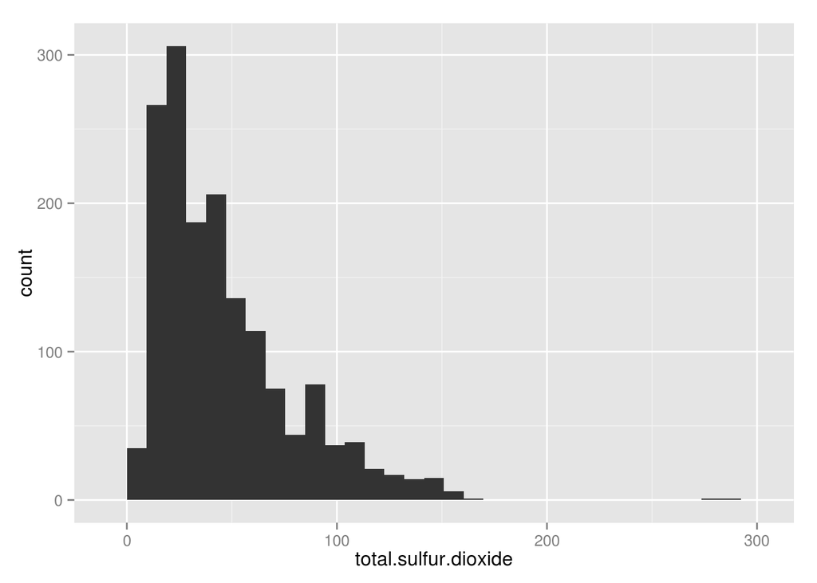

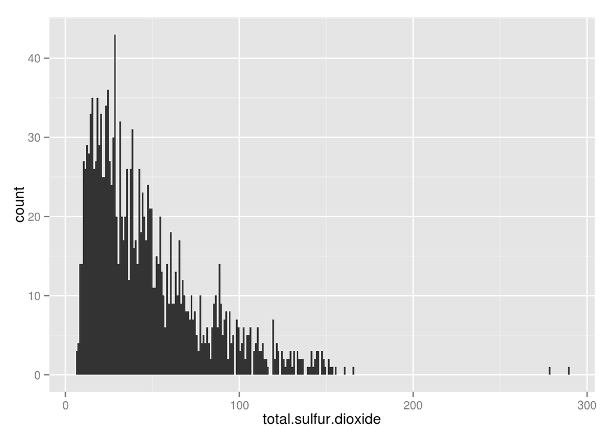

Again we will do a log tranform to the histogram since it is skewed.

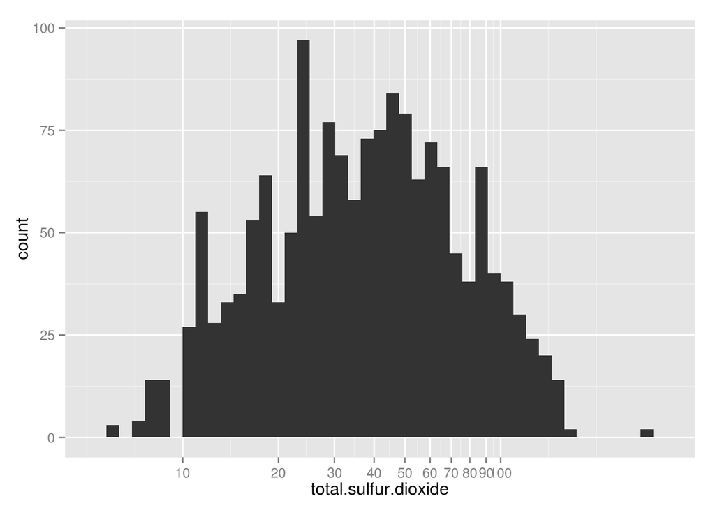

```
##
## 28 24 15 18 23 14
## 43 36 35 35 34 33
```

A value of 28 mg / dm^3 is common, note that we also see that most values of this variable are integers, just like the free sulfur dioxide variable.

```
## stat_bin: binwidth defaulted to range/30. Use 'binwidth = x' to adjust this.
```

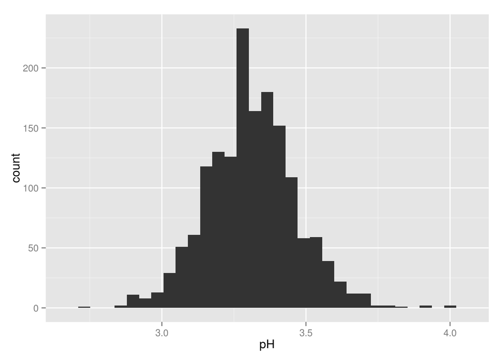

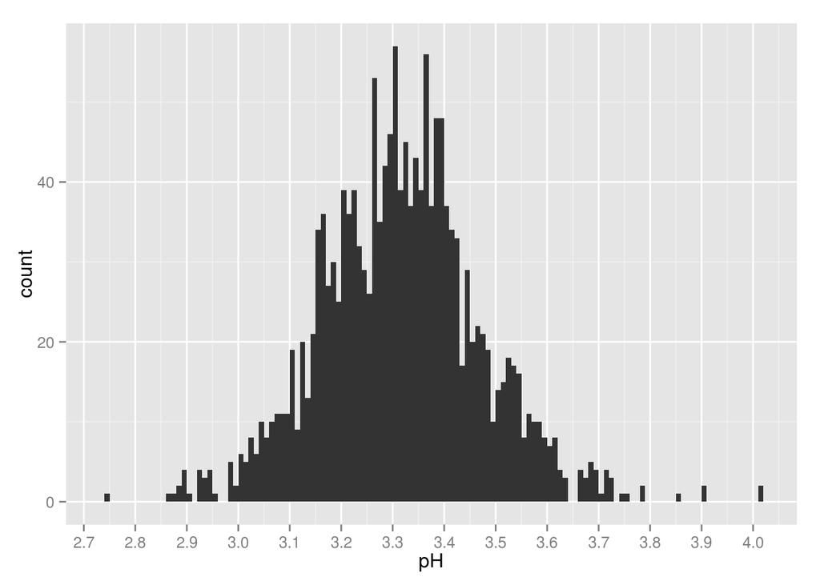

A value of ~ 3.3 for pH is common. Mean is 3.3111132 and median is 3.31

```
## stat_bin: binwidth defaulted to range/30. Use 'binwidth = x' to adjust this.
```

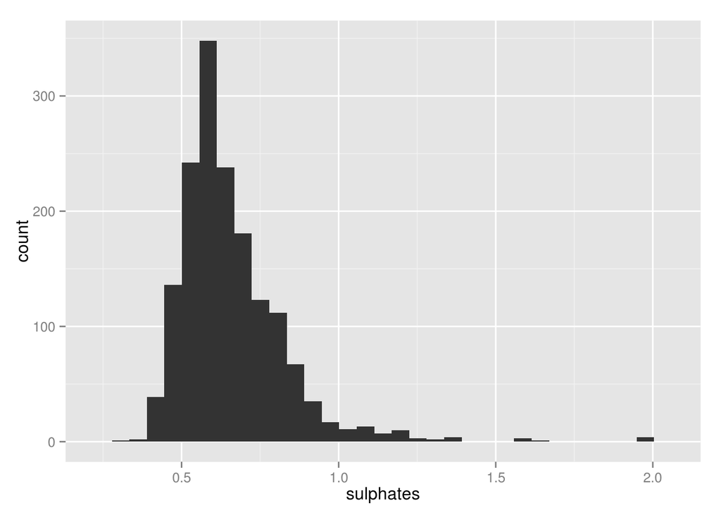

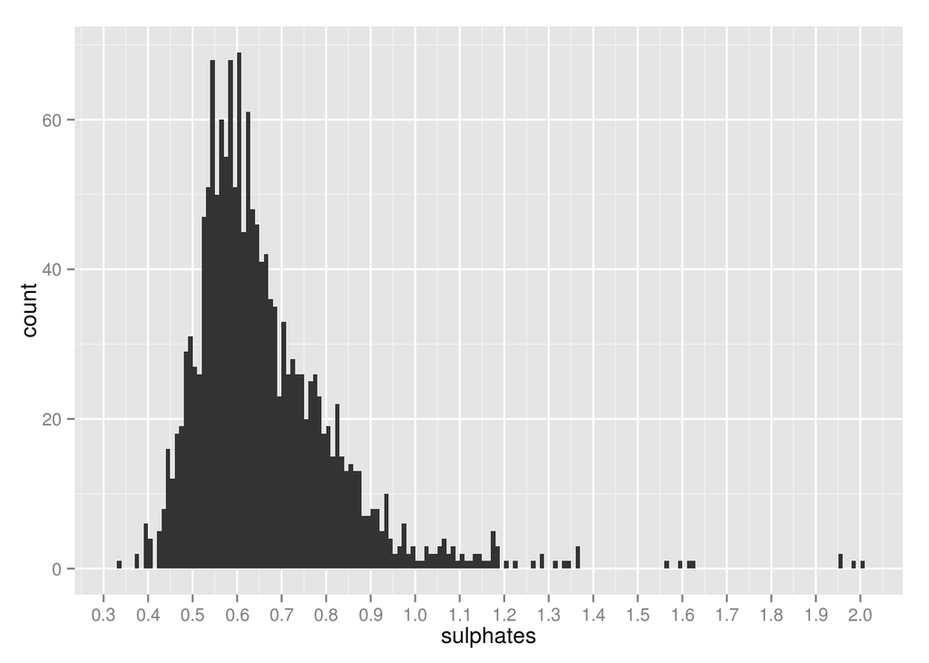

A value of 0.6 g / dm3 sulphates is common. The means is 0.6581488 and the median is 0.62

# Univariate Analysis

#### What is the structure of your dataset?

The dataset consists of 1599 red wines with 12 features fixed.acidity, volatile.acidity, citric.acid, residual.sugar, chlorides, free.sulfur.dioxide, total.sulfur.dioxide, density, pH, sulphates, alcohol, quality

Other observations:  
- Most wines have a quality rating of 5 or 6  
- Most wines have around 10% alcohol  
- Most wines have 2g / dm^3 of residual sugar

#### What is/are the main feature(s) of interest in your dataset?

- Alcohol
- Residual Sugar
- Density
- Chlorides

Though i think density is correlated with both alcohol and residual sugar. We will see if that’s the case in the bivariate plots section.

#### What other features in the dataset do you think will help support your investigation into your feature(s) of interest?

I think every other feature can be supportive in the investigation.

#### Did you create any new variables from existing variables in the dataset?

No

#### Of the features you investigated, were there any unusual distributions? Did you perform any operations on the data to tidy, adjust, or change the form of the data? If so, why did you do this?

There were some skewed distributions of variables (for e.g free and total sulfur dioxides), so i log transformed them to try to get an approximately normal distribution. Also i changed the binwidth on pretty much every plot i made to explore trends more accurately.

# Bivariate Plots Section

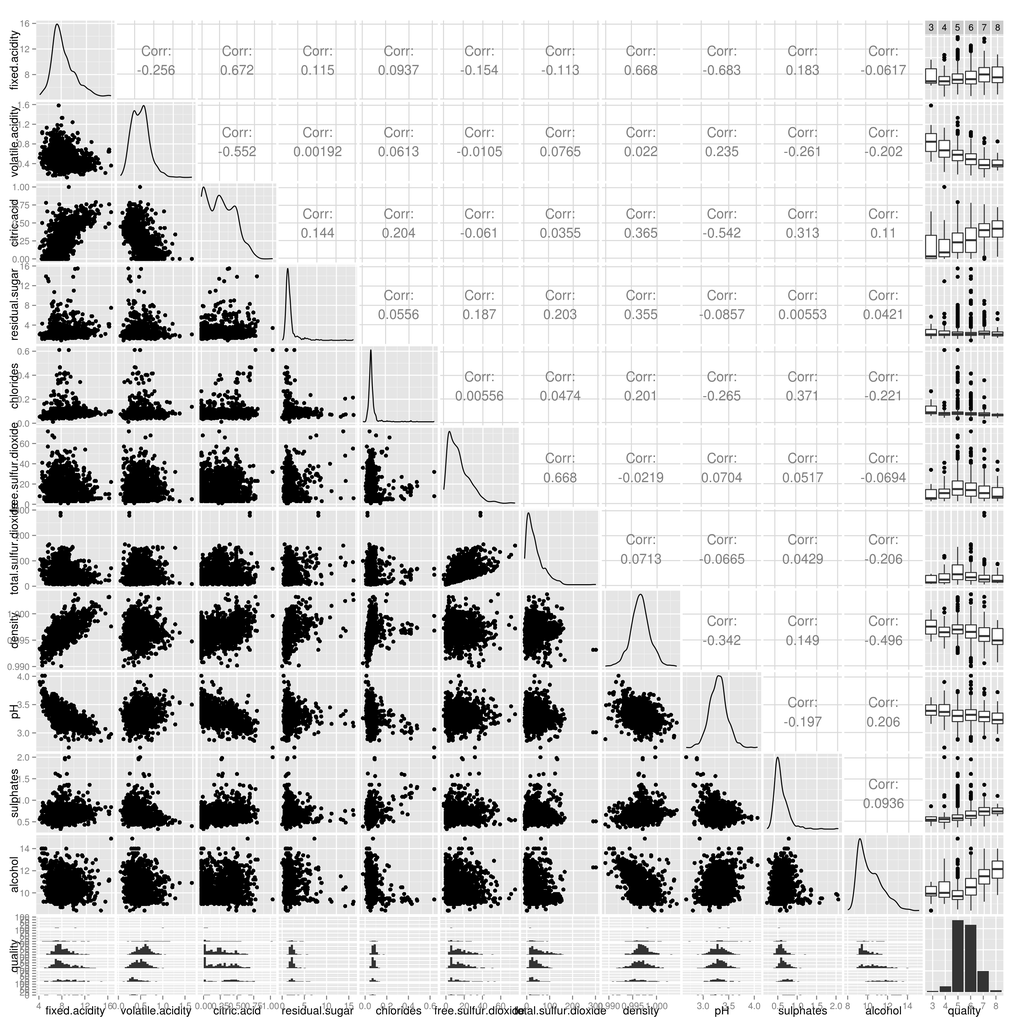

We can see that our intuition about density might be correlated with alcohol and residual sugar was somewhat correct.

- Correlation coefficient between density and alcohol is -0.496 (kind of strong)
- Correlation coefficient between density and residual sugar is 0.355 (kind of strong)

Also notice that in the last column quality seems to have a strong relationship with alcohol (as we expected earlier) but also it seems to have a strong relationship with citric acid.

We will continue to explore these 2 variables (and possibly others as well) against our featrue of interest `quality`.

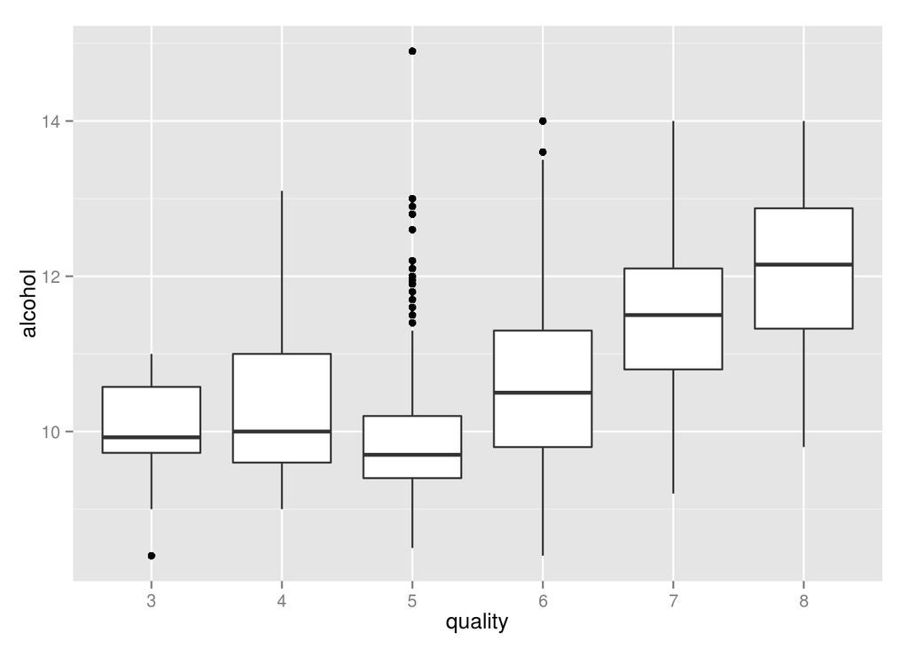

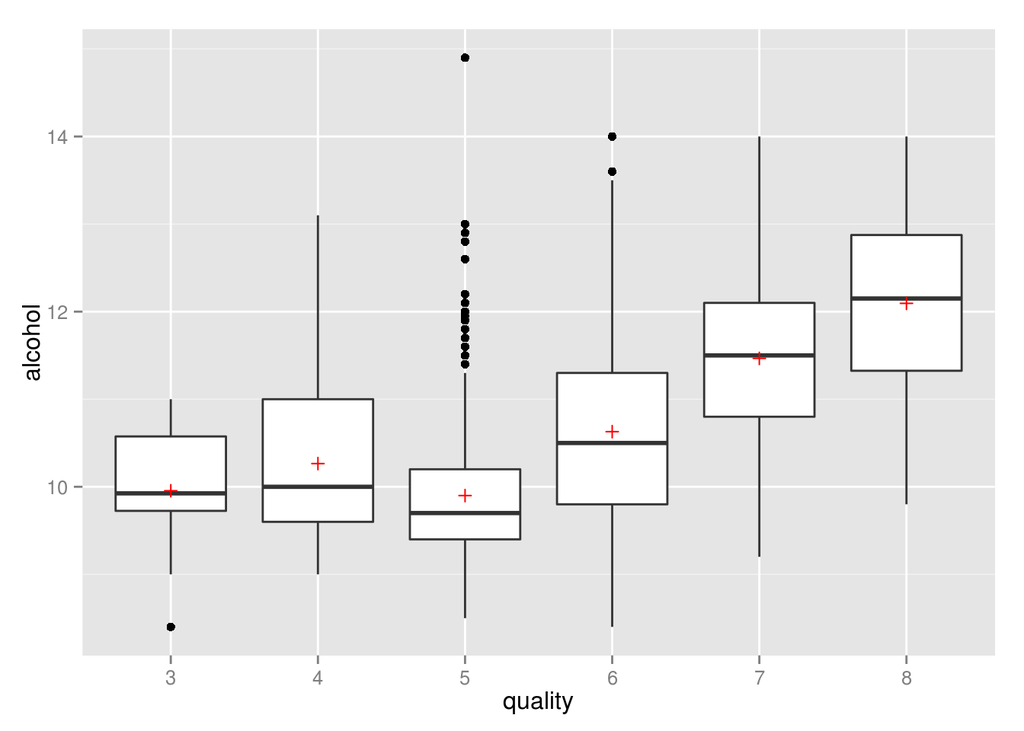

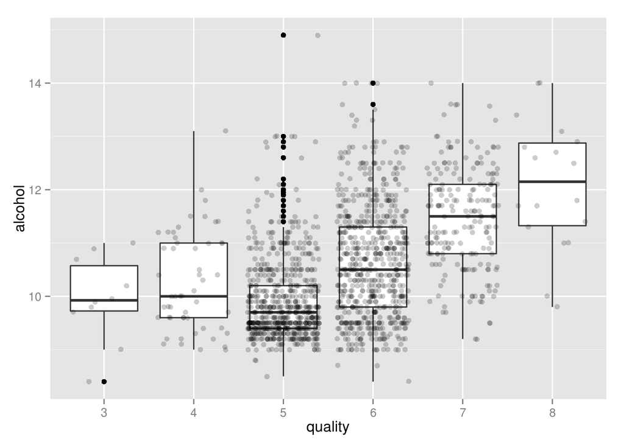

Clearly we can see from this plot that for higher alcohol levels, the quality tends to increase as indicated by the thick black lines indicating the medians.

Also it’s important to note that there is a lot of outliers at quality `5`. There is some wines with high level of alcohol but have a rather lower quality. There must be some other factors affecting quality.

In the second version of the plot, the mean is represented by a `+`. Again our relationship holds.

In the third version of the plot, i overlayed the actual points so that we can see that there is enough observations on each box (except maybe the first one and the last one) so that we can safely confirm that our relationship is solid.

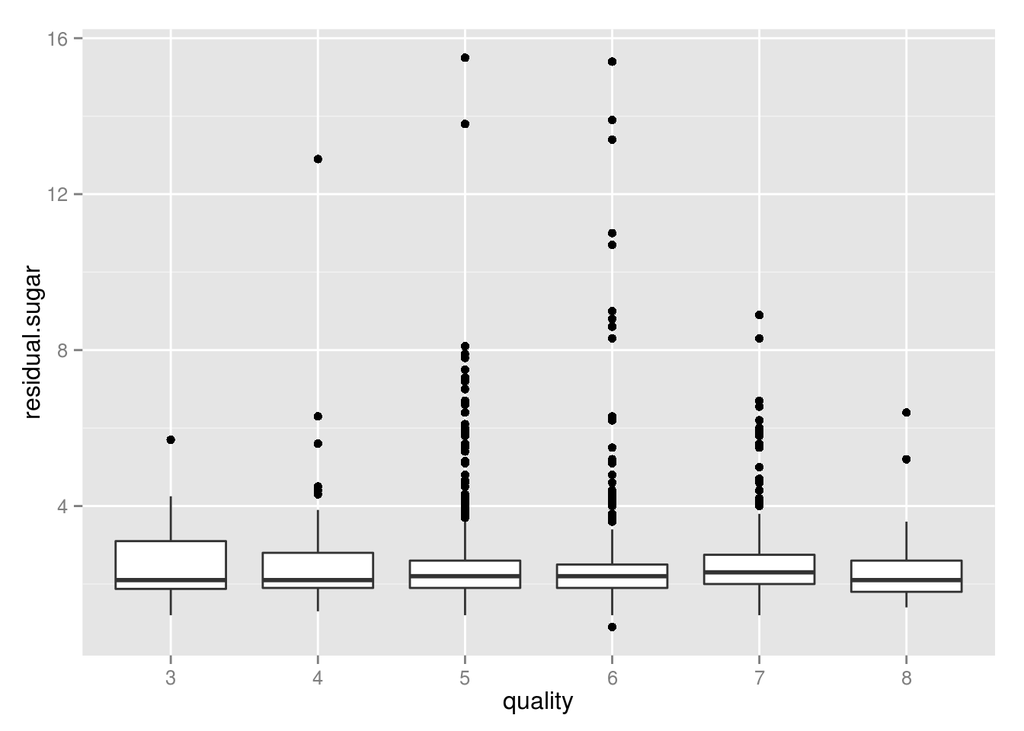

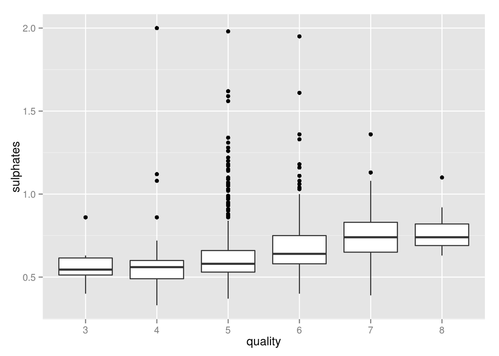

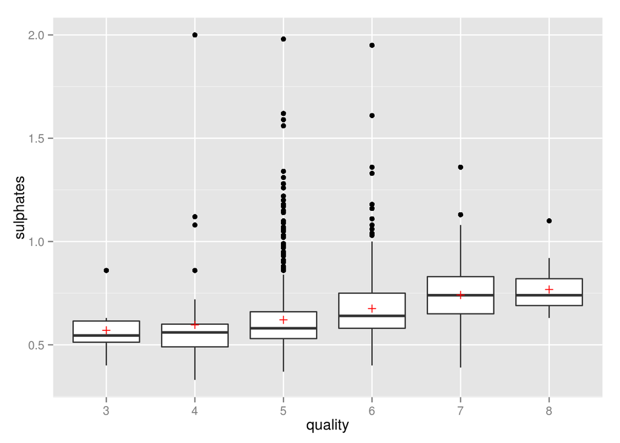

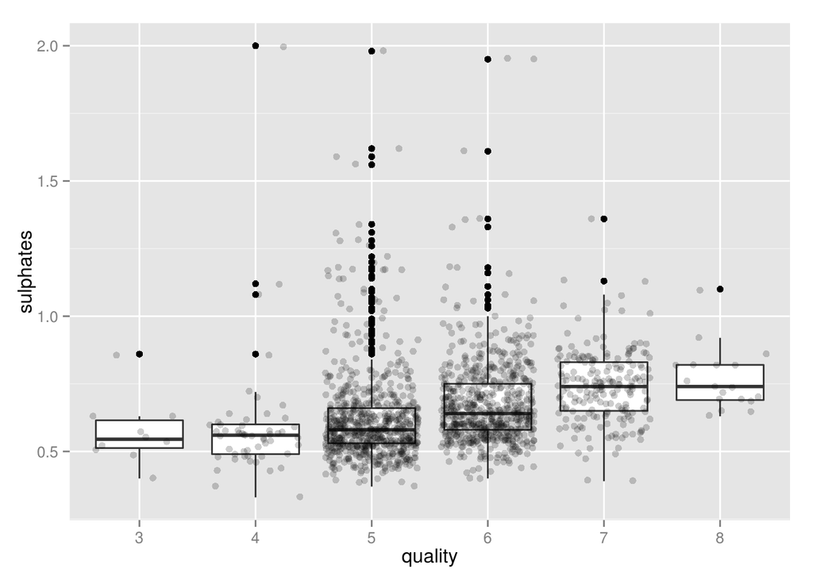

Quality stays lower at lower sulphates levels, then tends to increase as the sulphates increases.

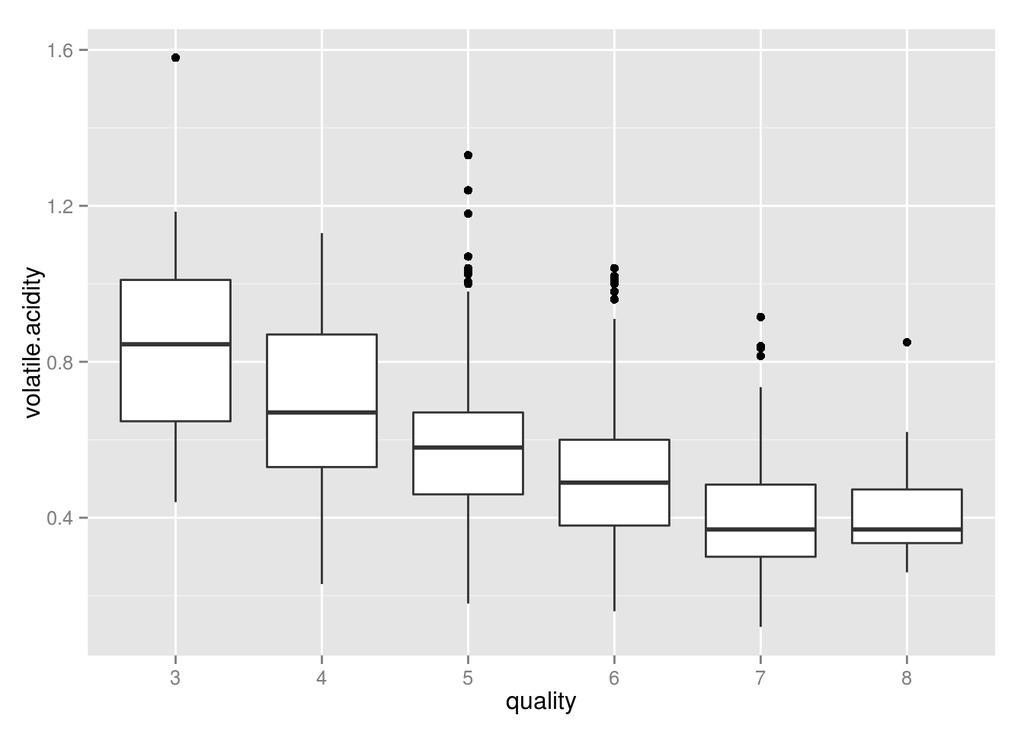

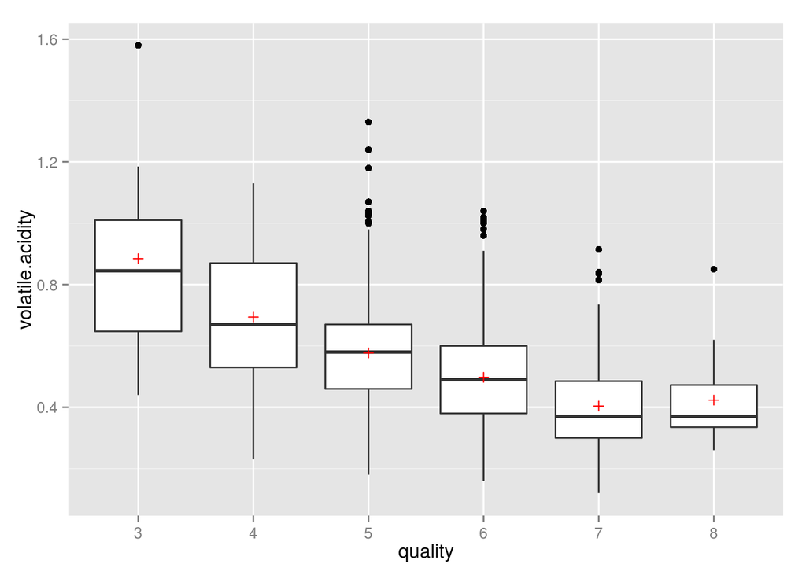

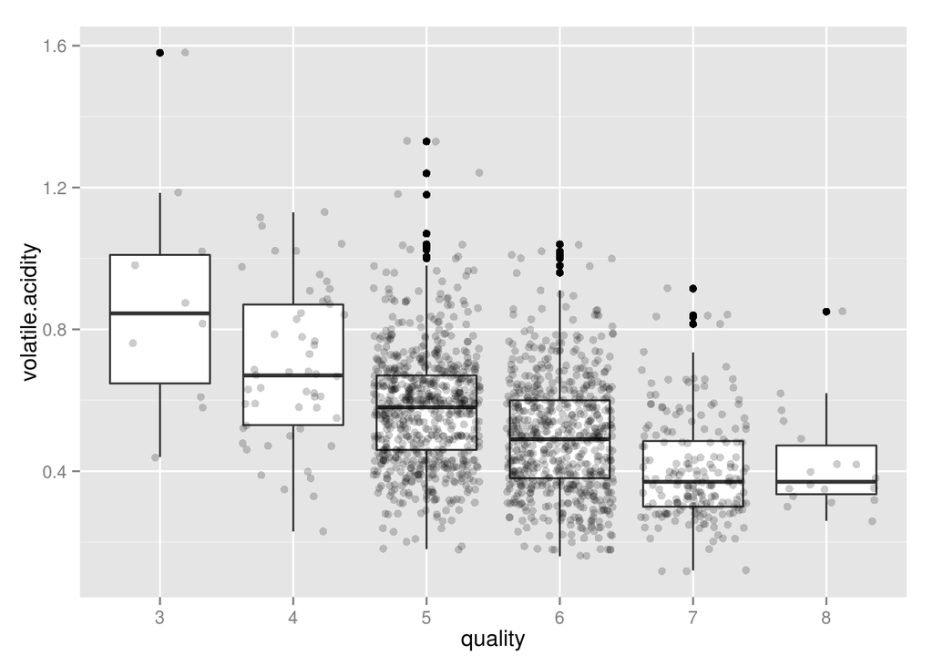

From the definition of `Volatile acidity`: **the amount of acetic acid in wine, which at too high of levels can lead to an unpleasant, vinegar taste**. So it makes a lot of sense to see bad wine qualities at higher levels of volatile acidity, this is verified by this plot. At quality 3 (bad quality) the volatile acidity has a median of ~ 0.8 and at Higher quality (7 & 8) the median volatile acidity is ~ 0.4.

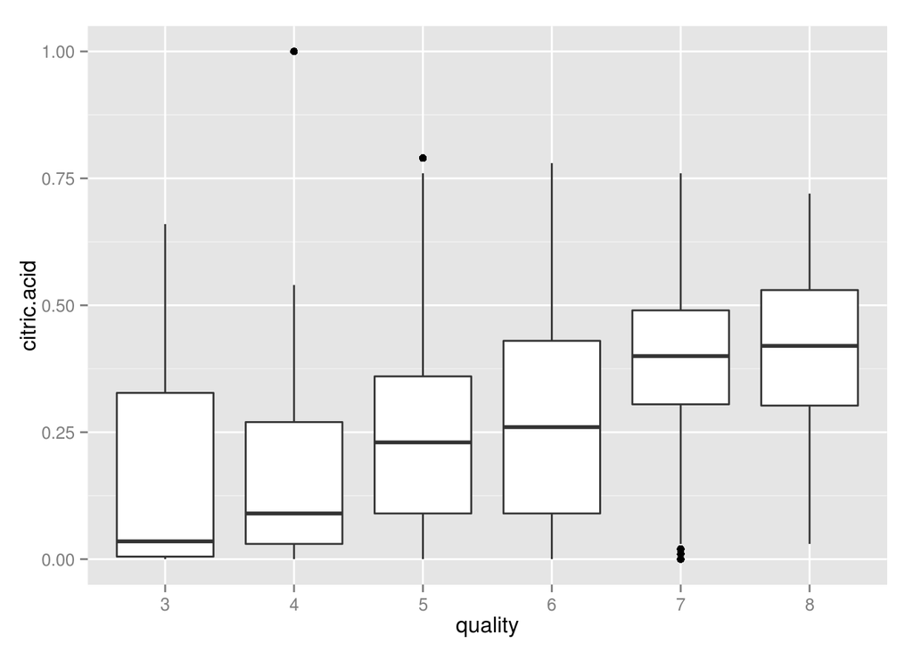

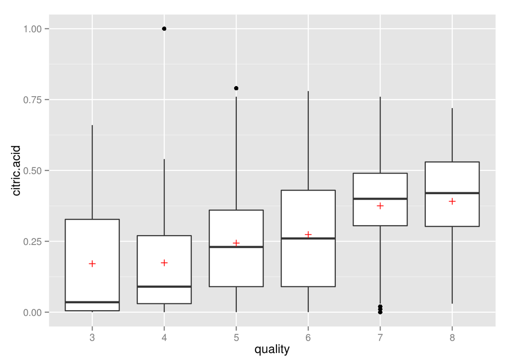

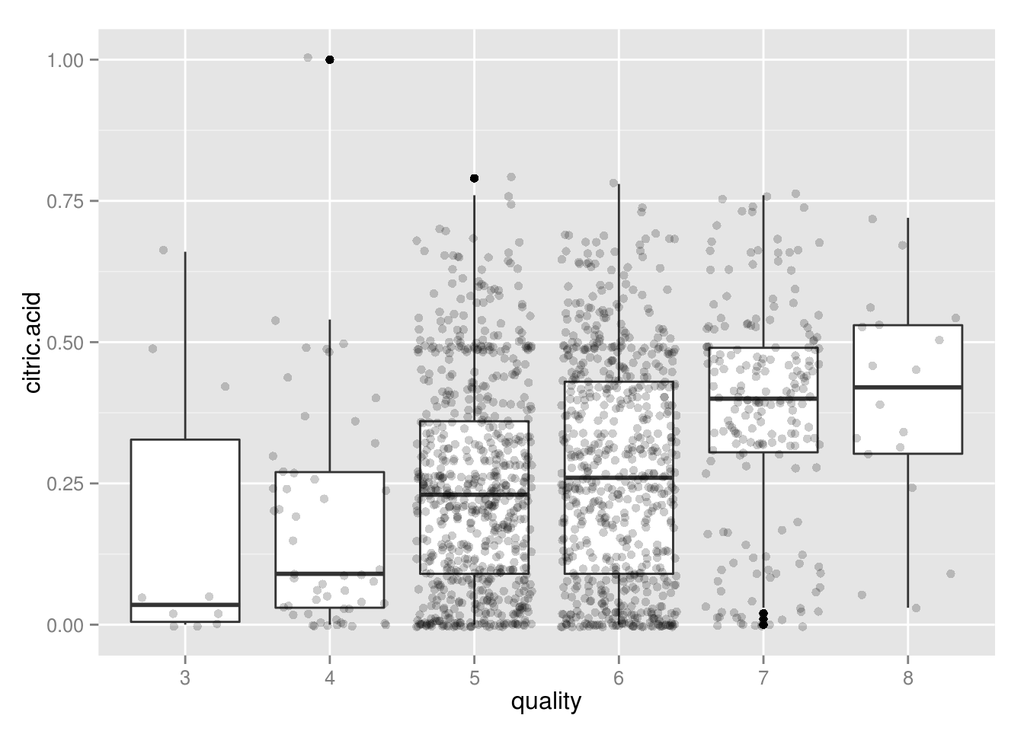

Quality stays low (3 & 4) at lower citric acid levels, tends to increase at higher levels of citric acid ( ~ 0.25). We get the best quality (7 & 8) at citric acid levels of ~ 0.375.

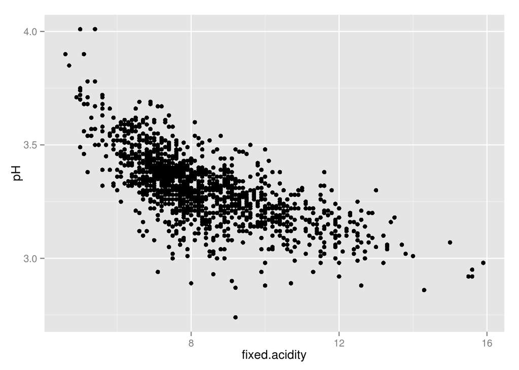

we can see an approximately linear relationship between fixed acidity and pH, as the amount of fixed acidity increase, pH levels decrease. This is to be expected from the definition of `pH`: **describes how acidic or basic a wine is on a scale from 0 (very acidic) to 14 (very basic); most wines are between 3-4 on the pH scale**

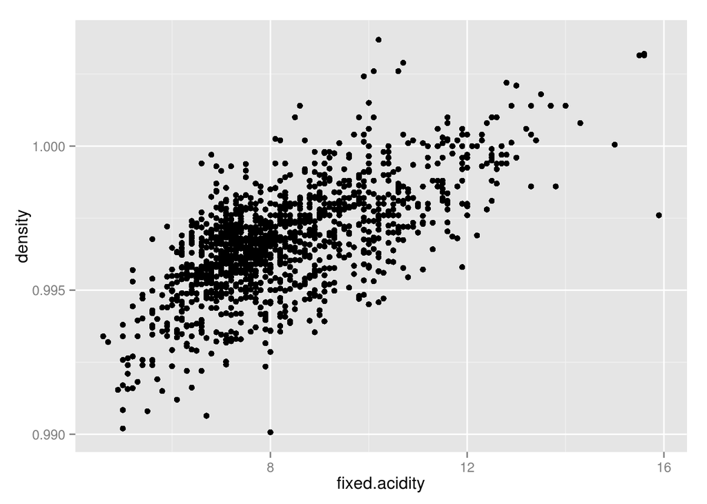

Here, as the fixed acidity increase density increase.

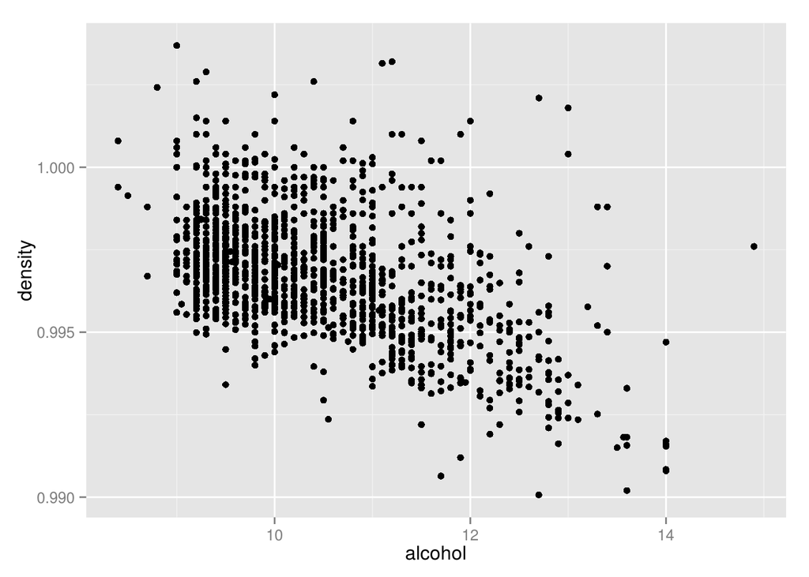

There seems to be an approximately linear trend between alcohol and density, as alcohol increase density decreases.

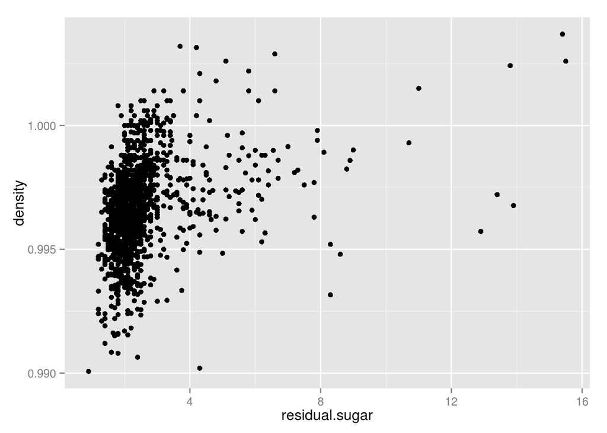

# Bivariate Analysis

#### Talk about some of the relationships you observed in this part of the investigation. How did the feature(s) of interest vary with other features in the dataset?

We observed some of the variables (sulphates, volatile acidity, residual sugar and alcohol) and explored their relationship with quality which is the main feature of interest. Here’s the summary of the relationships we observed

- Sluphates: Strong (+ve) relationship
- volatile acidity: Strong (-ve) relationship
- residual sugar: Very weak relationship
- alcohol: Very Strong (+ve) relationship
- citric acide: Strong (+ve) relationship

**Note**: Here (+ve) means as the indicated variable increase, quality tends to increase and (-ve) means as it increases, quality tends to decrease.

#### Did you observe any interesting relationships between the other features (not the main feature(s) of interest)?

From the pairs plot, we can see a relationship between both:

- Fixed acidity & pH
- Fixed acidity & density
- density & Alcohol

#### What was the strongest relationship you found?

It was between alcohol and quality.

# Multivariate Plots Section

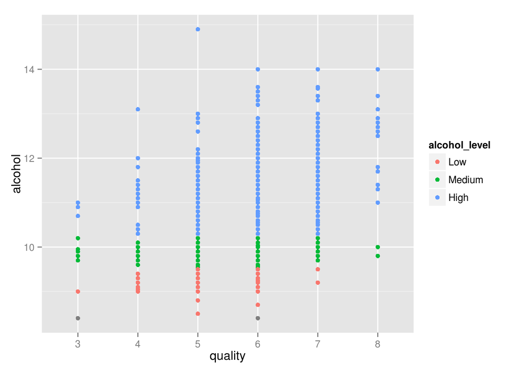

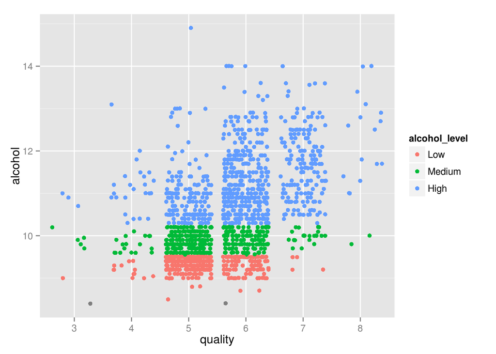

This plot revisits the relationship between quality and alcohol, but this time we took into account the alcohol level in the wine. As it turns out, Higher quality is generally associated with higher levels of alcohol (blue dots). Ofcourse, there is maybe some noise at quality levels 5 & 6 as they also have a considerable amounts of medium and lower alcohol levels.

# Multivariate Analysis

# Final Plots and Summary

# Reflection